# Downstream analysis of single-cell RNA-seq droplet data

2019-07-10

This workflow is adapted from portions of the [simpleSingleCell Bioconductor workflow](https://www.bioconductor.org/help/workflows/simpleSingleCell/) by Aaron Lun, Davis McCarthy, and John Marioni. Some sections have been simplified, additional material has been added exploring additional methods, and exercises have been added.

# 1 Load data object created in previous vignette

Here we continue our analysis of the peripheral blood mononuclear cell (PBMC) dataset from 10X Genomics (Zheng et al. 2017) that we began in the previous vignette “Preprocessing and normalization of single-cell RNA-seq droplet data”. We’ll load in the `SingleCellExperiment` object we previously saved.

```r
sce <- readRDS(file="pbmc_postQC.rds")
```

# 2 Dimensionality reduction

We use the `denoisePCA()` function with the assumed Poisson technical trend to choose the number of dimensions to retain after PCA. Recall that this involves a random initialization when `BSPARAM=IrlbaParam()`, which motivates the call to `set.seed()` to obtain reproducible results.

```r
library(scran)
library(BiocSingular)
new.trend <- makeTechTrend(x=sce)
set.seed(1000)
sce <- denoisePCA(sce, technical=new.trend, BSPARAM=IrlbaParam())
ncol(reducedDim(sce, "PCA"))
```

```
## [1] 14
```

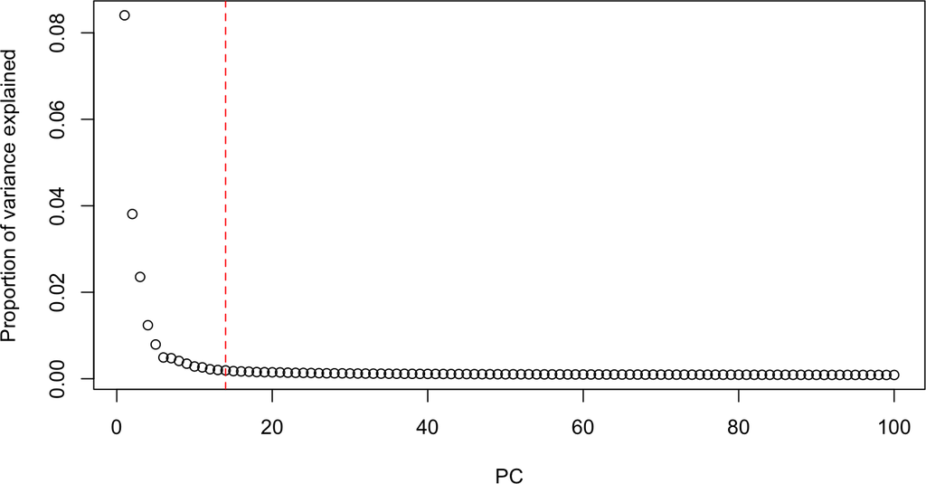

Figure 1: Variance explained by each principal component in the PBMC dataset  
The red line represents the chosen number of PCs.

```r
plot(attr(reducedDim(sce), "percentVar"), xlab="PC",
    ylab="Proportion of variance explained")
abline(v=ncol(reducedDim(sce, "PCA")), lty=2, col="red")
```

Examination of the first few PCs already reveals some strong substructure in the data (Figure 2).

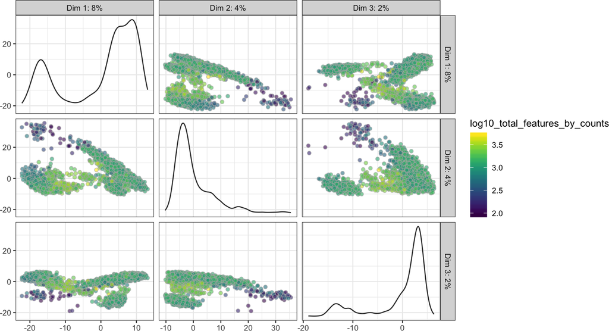

Figure 2: Pairwise PCA plots of the first three PCs in the PBMC dataset, constructed from normalized log-expression values of genes with positive biological components  
Each point represents a cell, coloured by the log-number of expressed features.

```r
plotPCA(sce, ncomponents=3, colour_by="log10_total_features_by_counts")
```

This is recapitulated with a *t*-SNE plot (Figure 3). Again, note that we set `use_dimred=` to perform *t*-SNE on the denoised expression matrix.

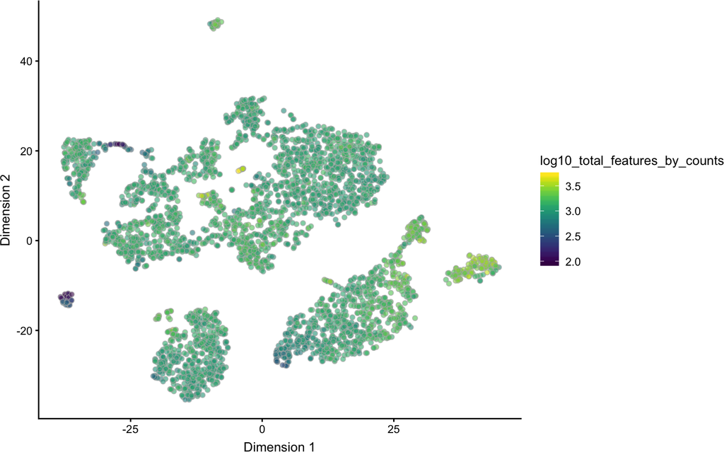

Figure 3: *t*-SNE plots constructed from the denoised PCs of the PBMC dataset  
Each point represents a cell and is coloured according to the log-number of expressed features.

```r
set.seed(1000)
library(scater)
sce <- runTSNE(sce, use_dimred="PCA", perplexity=30)
plotTSNE(sce, colour_by="log10_total_features_by_counts")
```

# 3 Clustering with graph-based methods

We build a shared nearest neighbour graph (Xu and Su 2015) and use the Walktrap algorithm to identify clusters.

```r
snn.gr <- buildSNNGraph(sce, use.dimred="PCA")
clusters <- igraph::cluster_walktrap(snn.gr)
sce$Cluster <- factor(clusters$membership)
table(sce$Cluster)
```

```
##
##   1   2   3   4   5   6   7   8   9  10  11  12  13
## 565 735 505 516 196 129 823  23 152  86  45  54  36
```

We look at the ratio of the observed and expected edge weights to confirm that the clusters are modular. (We don’t look at the modularity score itself, as that varies by orders of magnitudes across clusters and is difficult to interpret.) Figure 4 indicates that most of the clusters are well seperated, with few strong off-diagonal entries.

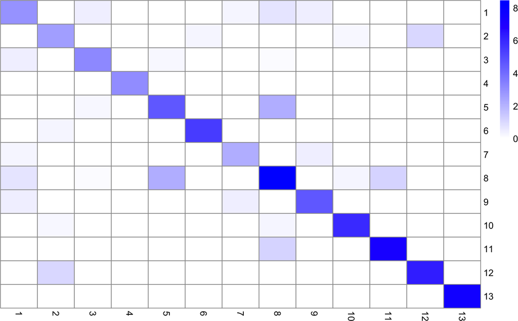

```r
cluster.mod <- clusterModularity(snn.gr, sce$Cluster, get.values=TRUE)
log.ratio <- log2(cluster.mod$observed/cluster.mod$expected + 1)

library(pheatmap)
pheatmap(log.ratio, cluster_rows=FALSE, cluster_cols=FALSE,
    color=colorRampPalette(c("white", "blue"))(100))
```

We examine the cluster identities on a *t*-SNE plot (Figure 5) to confirm that different clusters are indeed separated.

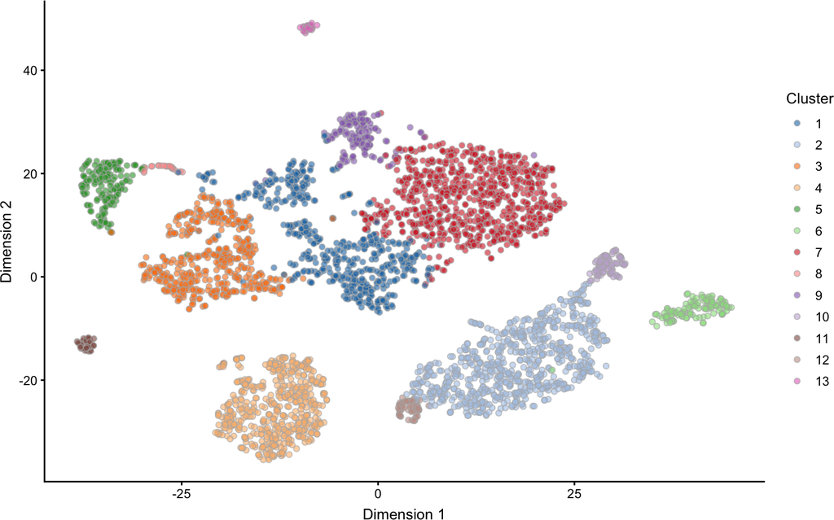

Figure 5: *t*-SNE plots constructed from the denoised PCs of the PBMC dataset  
Each point represents a cell and is coloured according to its cluster identity.

```r
plotTSNE(sce, colour_by="Cluster")
```

# 4 Marker gene detection

We detect marker genes for each cluster using `findMarkers()`. Again, we only look at upregulated genes in each cluster, as these are more useful for positive identification of cell types in a heterogeneous population.

```r
markers <- findMarkers(sce, clusters=sce$Cluster, direction="up")
```

We examine the markers for cluster 11 in more detail. The upregulation of genes such as *PF4* and *PPBP* suggests that this cluster contains platelets or their precursors.

```r
marker.set <- markers[["11"]]
head(marker.set[,1:8], 10) # only first 8 columns, for brevity
```

```
## DataFrame with 10 rows and 8 columns
##              Top              p.value                  FDR          logFC.1
##        <integer>            <numeric>            <numeric>        <numeric>
## PF4            1 6.28058528609359e-35 2.11618040629637e-30 7.16846707793473
## TMSB4X         2 1.92446083291372e-28 3.24213916520974e-24  3.3941139236655
## TAGLN2         2 7.86055241279841e-25 8.82844843322767e-21 4.87091175267208
## SDPR           2 6.84886562860166e-22 5.76914196225258e-18 5.87643719217314
## GPX1           3 4.76028831441971e-21 2.67321924110096e-17 5.40190202987622
## NRGN           3 2.58237079546306e-21 1.74020803164666e-17 5.28281780087229
## ACTB           5 2.00654135629128e-19 8.45105055735981e-16 3.80949580458417
## PPBP           5  4.4913820180667e-20 2.16189465309627e-16 6.70037851268117
## B2M            7 2.66682949274218e-18 8.16874117531409e-15 1.55668194505626
## CCL5           7 2.27184007045295e-18 7.65473793338418e-15 4.88914525715329
##                 logFC.2          logFC.3          logFC.4          logFC.5
##               <numeric>        <numeric>        <numeric>        <numeric>
## PF4    7.11287771614264 7.17262670948633 7.17425145832864 7.16625105021795
## TMSB4X 3.01775408662492 3.42858310480089 4.00452968272384 3.66349995784121
## TAGLN2 5.10305509740618 5.08392675449485 4.78400284684892  5.0885363027083
## SDPR   5.82450684481887 5.88478872421586 5.87829929019499 5.88478872421586
## GPX1   3.10200103625622 5.56962150548998 5.12898098399559 5.63360788247815
## NRGN   5.03487156700842 5.29013167534902 5.28651517539254 5.29027982081718
## ACTB   2.99331731645749 3.59644802749089 4.17748904870372 3.39816073989972
## PPBP   6.61064684130386  6.7102149815901 6.70219805695626 6.70888533406089
## B2M    2.05383271263196 1.36599070200891 2.25603711809116 1.55230725280685
## CCL5   5.59185919742997 1.88398969331623 5.55076080763556 3.37479798762217
```

This is confirmed in Figure 6, where the transcriptional profile of cluster 11 is clearly distinct from the others.

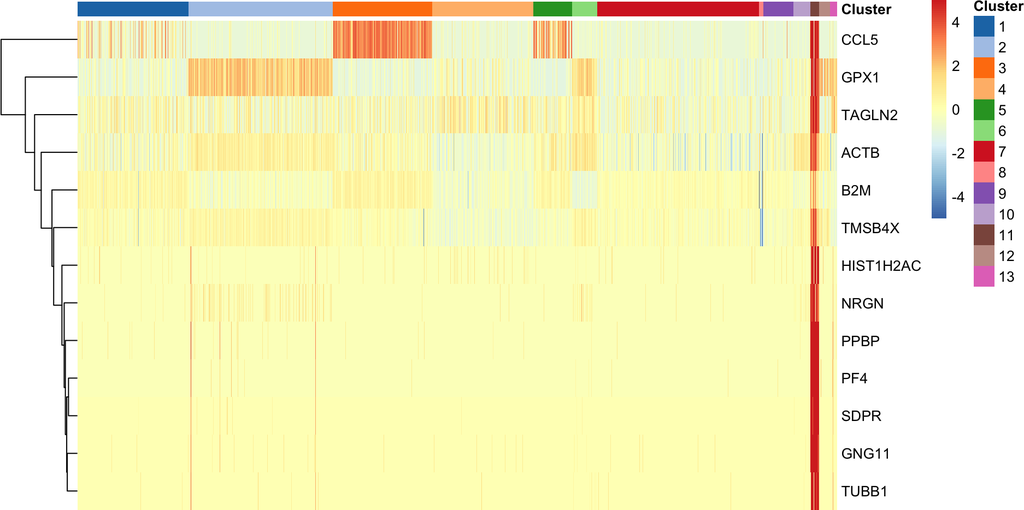

Figure 6: Heatmap of mean-centred and normalized log-expression values for the top set of markers for cluster 11 in the PBMC dataset  
Column colours represent the cluster to which each cell is assigned, as indicated by the legend.

```r
chosen <- rownames(marker.set)[marker.set$Top <= 10]
plotHeatmap(sce, features=chosen, exprs_values="logcounts",
    zlim=5, center=TRUE, symmetric=TRUE, cluster_cols=FALSE,
    colour_columns_by="Cluster", columns=order(sce$Cluster),
    show_colnames=FALSE)
```

# 5 Exercises

## 5.1 Parameters of SNN graphs

Here we’ll explore how different clusterings can be obtained just by varying the input parameters of the SNN graph. Use the `buildSNNGraph(sce, use.dimred="PCA")` function as before to build the graph, this time varying `k` = the number of nearest neighbors to consider (default is 10). Cluster on the graph as before using the Walktrap algorithm. You can also vary other input parameters as described in `?buildSNNGraph`. Compare your new clustering with the original in `sce$Cluster` with a table.

```r
snn.gr <- buildSNNGraph(sce, use.dimred="PCA", k = 40)
clusters <- igraph::cluster_walktrap(snn.gr)
sce$Cluster2 <- factor(clusters$membership)
table(sce$Cluster, sce$Cluster2)
```

```
##
##        1   2   3   4   5   6   7   8   9  10
##   1    0 524  14   0   0   1   0  26   0   0
##   2  726   0   1   0   8   0   0   0   0   0
##   3    0  20 485   0   0   0   0   0   0   0
##   4    0   0   1 515   0   0   0   0   0   0
##   5    0   2  33   0   0   0   0   0 161   0
##   6   12   0   0   0   0 117   0   0   0   0
##   7    0  13   0   0   0   0   0 810   0   0
##   8    0   0  18   0   0   0   0   0   5   0
##   9    0 145   0   0   0   0   0   7   0   0
##   10   0   0   0   0  86   0   0   0   0   0
##   11   0   0   0   0   0   0  45   0   0   0
##   12  54   0   0   0   0   0   0   0   0   0
##   13   0   0   0   0   0   0   0   0   0  36
```

Make a heatmap of the modularity score for your new clustering. Are you able to find a set of clustering parameters that reduces the amount of strong off-diagnonal entries?

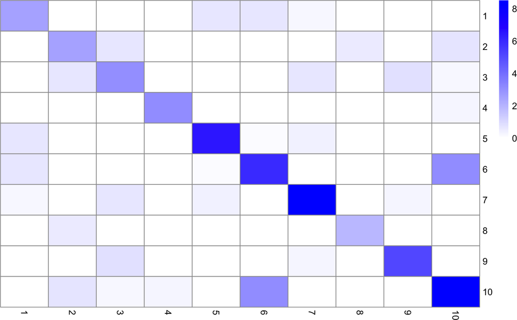

```r
cluster.mod <- clusterModularity(snn.gr, sce$Cluster2, get.values=TRUE)
log.ratio <- log2(cluster.mod$observed/cluster.mod$expected + 1)
library(pheatmap)
pheatmap(log.ratio, cluster_rows=FALSE, cluster_cols=FALSE,
    color=colorRampPalette(c("white", "blue"))(100))
```

## 5.2 Differential expression post-clustering on noise

Let’s explore the statistical consequences of carrying out a differential test following clustering on random noise. Use the following random matrix of 500 features for 200 samples. We first confirm with a PCA plot that there is no structure in a kmeans clustering of 2 clusters.

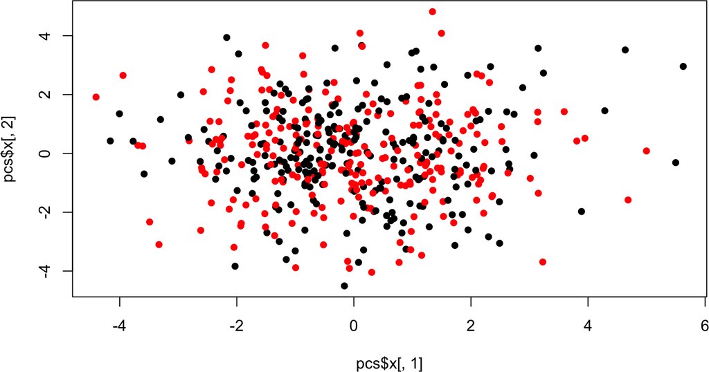

```r
set.seed(2)
y <- matrix(rnorm(100000), ncol=200)
clusters <- kmeans(t(y), centers=2)$cluster

pcs <- prcomp(y, center = TRUE,scale. = TRUE)
plot(pcs$x[,1], pcs$x[,2], pch=16, col=clusters)
```

Next, use the `findMarkers` function to find genes that separate the `clusters`. Make a histogram of the resulting p-values, and check for any that have an adjusted p-value less than 0.05.

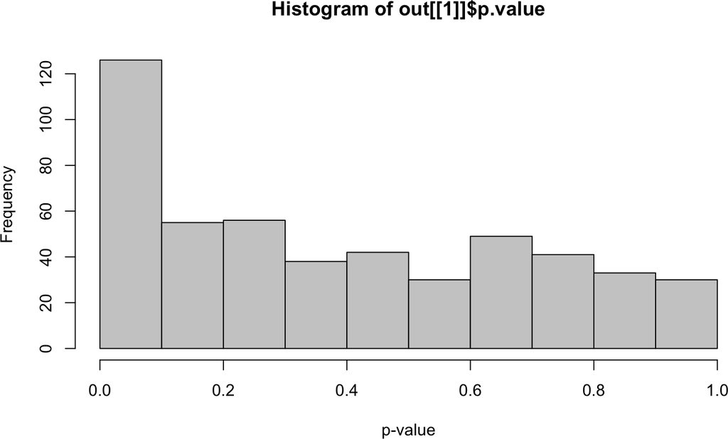

```r
out <- findMarkers(y, clusters)
hist(out[[1]]$p.value, col="grey80", xlab="p-value")
```

```r
sum(p.adjust(out[[1]]$p.value) < 0.05)
```

```
## [1] 3
```

# 6 Save object for future use

Having completed the basic analysis, we save the `SingleCellExperiment` object with its associated data to file. This avoids having to repeat all of the pre-processing steps described above prior to further analyses.

```r
saveRDS(sce, file="pbmc_data.rds")
```

# References

Xu, C., and Z. Su. 2015. “Identification of cell types from single-cell transcriptomes using a novel clustering method.” *Bioinformatics* 31 (12): 1974–80.

Zheng, G. X., J. M. Terry, P. Belgrader, P. Ryvkin, Z. W. Bent, R. Wilson, S. B. Ziraldo, et al. 2017. “Massively parallel digital transcriptional profiling of single cells.” *Nat Commun* 8 (January): 14049.